# tidyJSTOR Tutorial

## By Arthur Brackmann Netto

### HOPE Center 21/02/2020

# R and Data analysis

"R is a language and environment for statistical computing and graphics" (https://www.r-project.org/about.html)

R vs. Point-n-click

- Free
- Big community (RStats on twitter, stackoverflow, kaggle...)
- Big library of packages
- Reproducibility and transparency
- Bigger control over methods

# R Basics

Installation: R language and integrated development environment (IDE) (engine and dashboard)

- Language: https://www.r-project.org/  
  latest version: 3.6.2
- RStudio: https://rstudio.com/  
  Most commonly used IDE for R

Packages

- Packages: https://www.datacamp.com/community/tutorials/r-packages-guide  
  "R packages are collections of functions and data sets developed by the community. They increase the power of R by improving existing base R functionalities, or by adding new ones."

# Package Repositories

"A repository is a place where packages are located so you can install them from it." (https://www.datacamp.com/community/tutorials/r-packages-guide#what)

- GitHub: "We’re supporting a community where more than 40 million* people learn, share, and work together to build software."  
  https://github.com/  
  Non-peer reviewed, but open for modifications (pull requests)
- Comprehensive R Archive Network (CRAN): "CRAN is a network of ftp and web servers around the world that store identical, up-to-date, versions of code and documentation for R. Please use the CRAN mirror nearest to you to minimize network load."  
  https://cran.r-project.org/  
  Peer-reviewd packages

# tidyverse and tidyJSTOR

- tidyverse: https://www.tidyverse.org/ (CRAN)  
  "The tidyverse is an opinionated collection of R packages designed for data science. All packages share an underlying design philosophy, grammar, and data structures"  
  Obs: tidyverse vs. base R controversy (https://tidyverse.tidyverse.org/articles/manifesto.html)
- tidyJSTOR (GitHub)  
  "This package transforms JSTOR DFR's XML files into tidy dataframes and produces ggplot2 visualizations. This packages is a wrapper around tidyverse utilities and text-analisys tools intended for non-frequent R users to be able to realize bibliometric exploratory research of JSTOR datasets. Advanced R users may prefer to use the package solely for data transformation using JSTOR_df() and produce their own visualizations and analysis."

# Data Science Workflow

[figure not shown]

(from https://r4ds.had.co.nz/introduction.html)

# tidyJSTOR Workflow

[figure not shown]

# JSTOR DFR: First steps

[figure not shown]

# JSTOR DFR: creating and requesting a dataset

[figure not shown]

# JSTOR DFR: extracting

[figure not shown]

# JSTOR DFR: Search Tips and Tricks

Boolean Operators

- AND, OR, NOT, Parentheses
- ex: model AND (structural OR structuralist)

Wild cards, truncation and proximity

- bird*; wom?n; debt forgiveness~10; migration^7 geese

Specific phrases

- "history of economic thought"

Citations in JSTOR? Yes! Let's use the fact that JSTOR realizes full text searches.

- "Friedman (1953)"; or "The Methodology of Positive Economics"; or "Essays in Positive Economics"
- "Friedman (1953)" OR "The Methodology of Positive Economics" OR "Essays in Positive Economics"
- "Friedman" AND ("The Methodology of Positive Economics" OR "Essays in Positive Economics") AND 1953

# tidyJSTOR: installing packages

```r
#installing from CRAN
    #install.packages("tidyverse")
    library(tidyverse)

    #installing from GitHub
    #Necessary to install CRAN package: "devtools"
    #install.packages("devtools")
    #library(devtools)
    #install_github("arthurbnetto/tidyJSTOR")
    #alternatively devtools::install_github()
    library(tidyJSTOR)
```

# tidyJSTOR: import data

```r
coaseTheorem <- JSTOR_df("C:/Users/arthu/Google Drive/Economia/Doutorado/Tese/Dados/Abstracts JSTOR/coase theorem/metadata")
coase1937 <- JSTOR_df("C:/Users/arthu/Google Drive/Economia/Doutorado/Tese/Dados/Abstracts JSTOR/coase (1937)/metadata")
coase1960 <- JSTOR_df("C:/Users/arthu/Google Drive/Economia/Doutorado/Tese/Dados/Abstracts JSTOR/coase (1960)/metadata")
```

[output not shown]

# tidyJSTOR: plot_search

```r
docCount<-list(coaseTheorem, coase1937, coase1960)
```

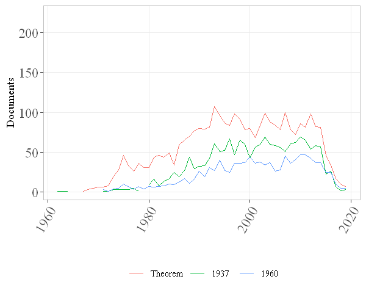

```r
plot_search(docCount, c("Theorem", "1937", "1960"))
```

```
Warning message:
"Removed 17 rows containing non-finite values (stat_smooth)."
```

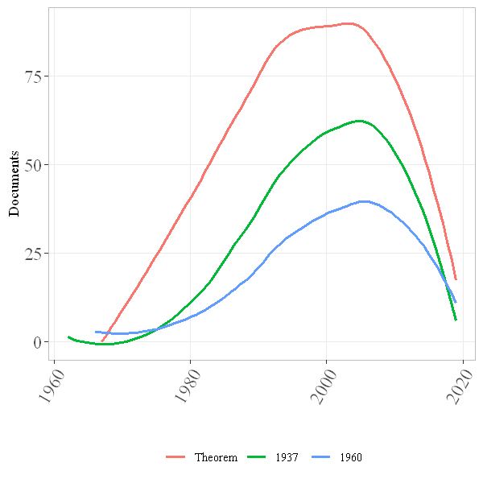

```r
plot_search(docCount, c("Theorem", "1937", "1960"), smooth = TRUE)
```

# tidyJSTOR: JSTORplotJournals

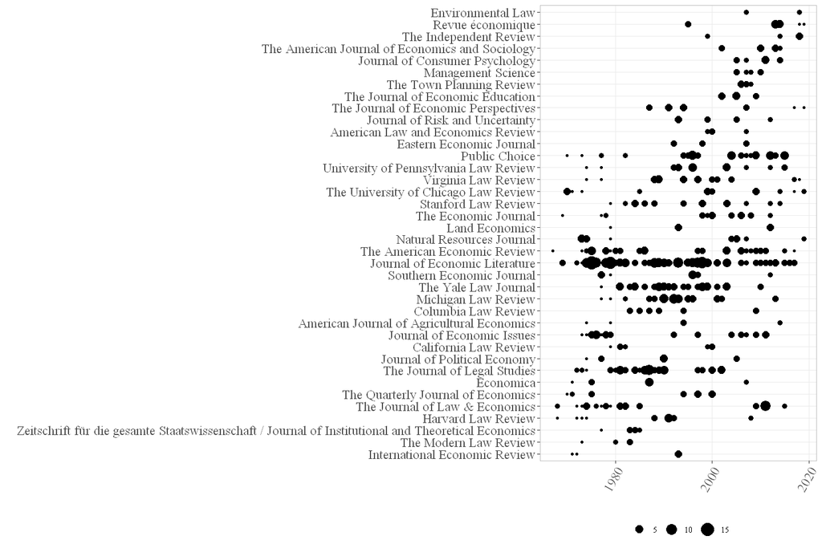

```r
JSTORplotJournals(coaseTheorem, 5, 3)
```

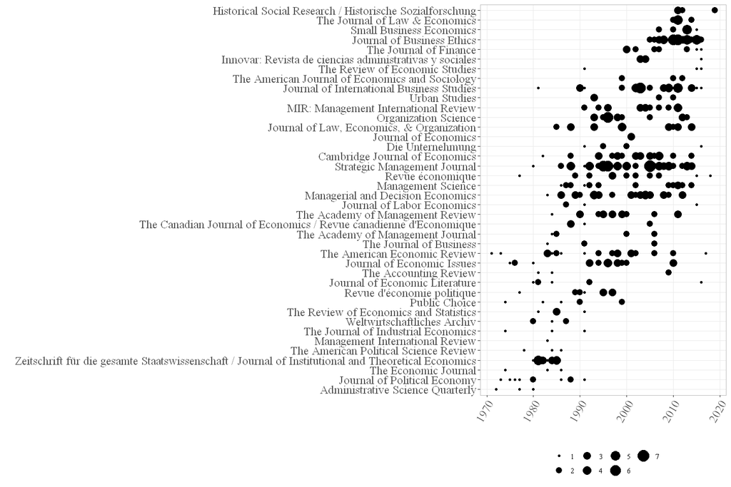

```r
JSTORplotJournals(coase1937, 5, 3)
```

# tidyJSTOR: compareJSTOR_dfs("Journal")

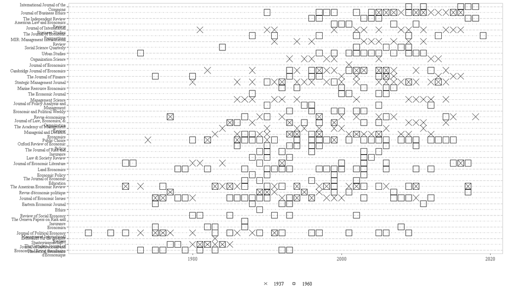

```r
suppressWarnings(compareJSTOR_dfs(coase1937, coase1960, 5,5, c("1937", "1960"), "Journal"))
```

# tidyJSTOR: Tidy

```
"Removed 14 rows containing missing values (geom_path)."
```

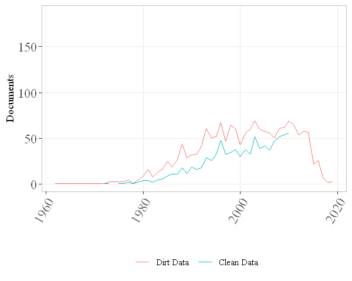

```r
coase1937Clean <- CleanJSTOR_df(coase1937)
plotCleaningResult(coase1937Clean, coase1937)
```

```
"Removed 13 rows containing missing values (geom_path)."
```

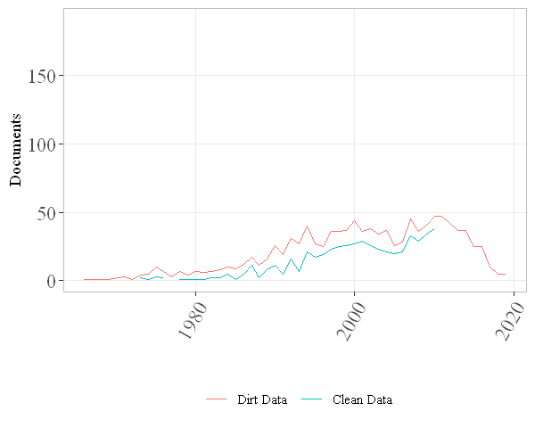

```r
coase1960Clean <- CleanJSTOR_df(coase1960)
plotCleaningResult(coase1960Clean, coase1960)
```

# tidyJSTOR: Repeated Top...

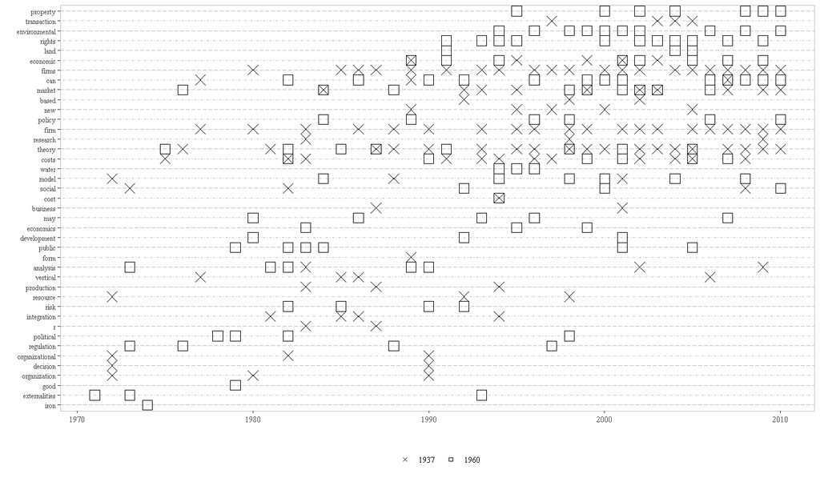

```r
suppressWarnings(compareJSTOR_dfs(coase1937Clean, coase1960Clean, 5,3, c("1937", "1960"), "Words"))
```

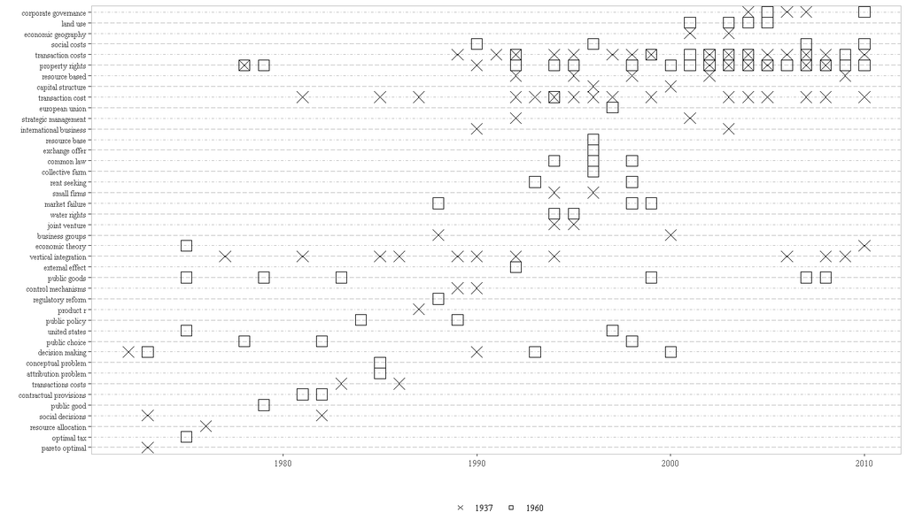

```r
suppressWarnings(compareJSTOR_dfs(coase1937Clean, coase1960Clean, 5,2, c("1937", "1960"), "Bigrams"))
```

# tidyJSTOR: VocabCount

```r
transaction <- c("transaction", "transactions")
vocab1937<-VocabCount(coase1937Clean, transaction)
vocab1960<-VocabCount(coase1960Clean, transaction)
transactionList<-list(vocab1937, vocab1960)
```

[output not shown]

```
Warning message:
"Removed 10 rows containing non-finite values (stat_smooth)."
```

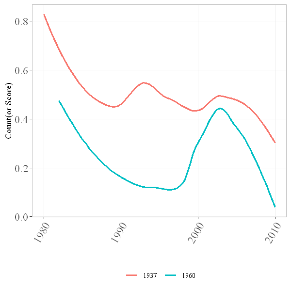

```r
JSTORplotVocabCount(transactionList, c("1937","1960"), smooth = TRUE)
```

```r
environmental <- "environmental"
vocab1937<-VocabCount(coase1937Clean, environmental)
vocab1960<-VocabCount(coase1960Clean, environmental)
environmentalList<-list(vocab1937, vocab1960)
```

[output not shown]

```
Warning message:
"Removed 10 rows containing non-finite values (stat_smooth)."
```

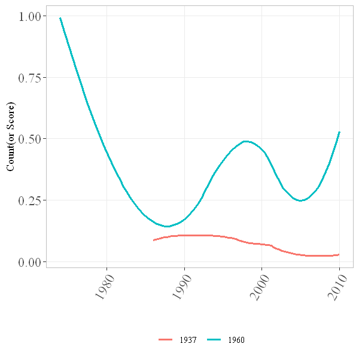

```r
JSTORplotVocabCount(environmentalList, c("1937","1960"), smooth = TRUE)
```